# Camera Calibration - Part3

### Introduction

In this post we'll discuss about how to obtain only intrinsic parameters of a camera, using **Zhang's Method**. Not taking into account where the camera is present. In contrast to [Direct Linear Transform](https://prithviramg.github.io/posts/Camera%20Calibration%20-%20Part2.html), where we estimate both intrisic and extrinsic parameters of camera calibration. We'll basically use checker board pattern, so it contains the known 2S structure for performing the localisation. This approach was proposed by Zhang more than 20 years ago, and it is more widely used approach for obtaining the camera intrisics.

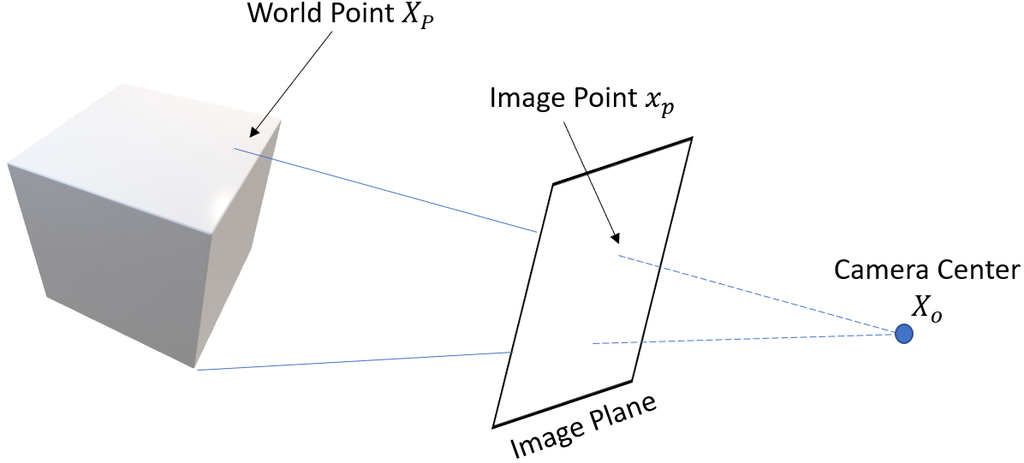

$$\begin{align*}(x_p)_{3 \times 1} &= \underbrace{K_{3 \times 3}}_\text{Intrisic Parameters} \quad \underbrace{\underbrace{R_{3 \times 3}}_\text{Rotation}[(I_3)_{3 \times 3} |\quad\underbrace{-(X_O)_{3 \times 1}}_\text{Translation}]}_{\text{Extrinsic Parameters}({3 \times 4})}(X_P)_{4 \times 1} \end{align*}$$ So in Zhang's method we are only interested in intrisics we dont care about where the camera is present. Before diving, its better to know about [intrisic and extrinsic parameters](https://prithviramg.github.io/posts/Camera%20Calibration%20-%20Part1.html) and [Direct Linear Transform](https://prithviramg.github.io/posts/Camera%20Calibration%20-%20Part2.html)

### Zhang's Method

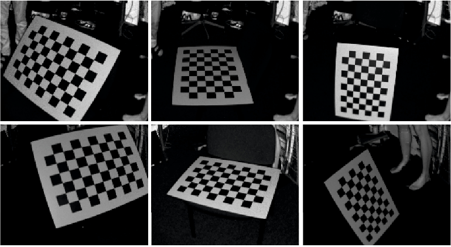

Unlike DLT method, we dont use 3D position here, but instead we use checkerboard pattern. We show this checkerboard pattern in front of camera and generate various images of this checkerboard with various positions. So we can exploit the assumption that it is a checkerboard and all points are on the plane. So what we can do is we simply run a corner detector on the images to find the corners. We dont know where the points are in 3D world, but we know for sure that these points will lie on a plane. We use a trick, for every image we define the coordinate system, coordinate system defined in such a way that x-y plane(z=0) defines the checkerboard and then we know size of the squares present on the checkerboard, often this is sufficient to estimate the intrinsic parameters.

#### Solving the Linear system (Homogeneous system => SVD)

- Solving a system of linear equations of the form $Ap = 0$ is equivalent to finding the null space of $A$, So the vector $p$ must be in null space of $A$
- Thus, we can apply the SVD to solve $Ap = 0$. Singular Value decomposition is technique to solve linear equations by finding the singular values and singular vectors and if we have a singular value which is equal to $0$, then that singular vector is part of the null space
- Choose $p$ as the singular vector belonging to the singular value of 0.
- Singular value Decomposition (SVD) $$ \underbrace{A}_{2I\times9} = \underbrace{U}_{2I\times9} \overbrace{S}^{9\times9} {\underbrace{V}_{9\times9}}^T = \sum_{i = 1}^{9}s_iu_i{v_i}^T$$
  - The SVD decomposes the matrix in to 3 matrices $U_{2I\times9}$, $S_{9\times9}$, and $V_{9\times9}$
  - The Matrix $S_{9\times9}$ is diagonal matrix, which contains the singular values in descending order, the largest value will be first and least value will be on the last of the diagonal vector
  - The smallest value $v_{9}$ will be our nullspace vector, if it zero then it is perfect, but typically it is not zero(close to zero)
  - The matrix $V_{9\times9}$ stores the singular vector, and we pick the vector which corresponds to the smallest singular value, use this vector as solution to our equation
- choosing $p = v_{9}$ (the singular vector belonging to the smallest singular value $s_{9}$) $$p = \begin{pmatrix}p_{11}\\p_{12}\\\vdots\\p_{33}\end{pmatrix} \implies \begin{pmatrix}p_{11}&p_{12}&p_{13}\\p_{21}&p_{22}&p_{23}\\p_{31}&p_{32}&p_{33}\end{pmatrix}$$

#### How to get K(intrisic Parameter) from P?

- Now We need to extract $K$ from the matrix $$\begin{align*} P_{3 \times 3} &= \underbrace{K_{3\times3}}_\text{intrisic paramter}\begin{pmatrix}\underbrace{r_{1}}_\text{rotation column1}&\underbrace{r_{2}}_\text{rotation column2}&t\end{pmatrix}_{3\times3}\\ &=\underbrace{\begin{pmatrix}p_1&p_2&p_3\end{pmatrix}}_\text{columnns of P} = \underbrace{\begin{pmatrix}c&cs&x_H\\0&c(1+m)&y_H\\0&0&1\end{pmatrix}_{3\times3}}_K\quad\underbrace{\begin{pmatrix}r_{11}&r_{12}&t_{1}\\r_{21}&r_{22}&t_{2}\\r_{31}&r_{32}&t_{3}\end{pmatrix}_{3\times3}}_{(r_{1},r_{2},t)} \end{align*}$$ we computed via SVD, we need break this matrix into 2 matrices, one is upper triangular matrix and other is where we know only 2 rotation and traslation vectors.
  - we need to get constraints about, what do we know about $K$,$r_1$ and $r_2$.
  - Then we'll define a matrix $B = K^{-T}K^{-1}$, we'll see that this term, pops up in forth coming equations we write down.
  - This $B$ can be computed by solving another homogeneous linear system.
  - Decompose matrix $B$.
- Now lets rewrite the above equation $$\begin{pmatrix}r_{1}&r_{2}&t\end{pmatrix} = K^{-1}\begin{pmatrix}p_1&p_2&p_3\end{pmatrix}$$ so eventually $$\implies r_1 = K^{-1}p_1 \quad r_2 = K^{-1}p_2$$ now we exploit the fact $r_1$ and $r_2$ comes from **rotation matrix**, so these 2 vectors should be orthonormal to each other. We can get 2 points from here
  - vectors orthonormal to each other, that mean s their dot product should be 0 $${r_1}^Tr_2 = 0$$
  - each vector should be of unit length $$||r_1||=||r_2||=1$$
- So by using the above constraints we arrive at $$\begin{align*} \overset{{r_1}^Tr_2 = 0}{\implies} \underbrace{{p_1}^TK^{-T}K^{-1}p_2}_\text{constraint 1} &= 0\\ \overset{||r_1||=||r_2||=1}{\implies} {p_1}^TK^{-T}K^{-1}p_1 &= {p_2}^TK^{-T}K^{-1}p_2\\ \underbrace{{p_1}^TK^{-T}K^{-1}p_1 - {p_2}^TK^{-T}K^{-1}p_2}_\text{constraint 2} &= 0\\ \end{align*}$$ now we substitute $B = K^{-T}K^{-1}$, symmetric and positive definite matrix: $$\begin{align*} \underbrace{{p_1}^TBp_2}_\text{constraint 1} &= 0\\ \underbrace{{p_1}^TBp_1 - {p_2}^TBp_2}_\text{constraint 2} &= 0\\ \end{align*}$$
- **Lets Dive deep and inspect the equations above**
  - By Knowing that $B$ consists of matrix transpose times a matrix, so there exists a matrix decomposition, that actually breaks up the symmetric and positive definite matrix into matrix times into its matrix transpose - **Cholesky Decomposition**
  - So if get the values $B$, we can compute the **Cholesky Decomposition** of $B$, and it breaks it into matrix times into its matrix transpose $$\begin{align*} Chol(B) &= AA^T\\ \implies A &= K^{-T} \end{align*}\\ \implies \text{If We know }B\text{,then we can compute }K$$
- **Lets write down knowns and unknowns**
  - $B$ consists of unknowns, since it is symmetric, we need to estimate only 6 unknowns instead of 9
  - $p$ are known
  - there 2 equations that relate $B$ and $p$
  - If We know $B$,then we can compute $K$
- Lets compute $B$
  - lets assume $B = \begin{pmatrix}a&b&c\\b&d&e\\c&e&f\end{pmatrix}$, symmetric and positive definite
  - $p_1 = \begin{pmatrix}p_{11}\\p_{21}\\p_{31}\end{pmatrix}$ and $p_2 = \begin{pmatrix}p_{12}\\p_{22}\\p_{32}\end{pmatrix}$
  - lets contruct the system of linear equations $Vb = 0$ exploting the previous constraints: $$\begin{align*} \overset{{p_1}^TBp_2}{\implies}\underbrace{{v_{12}}^Tb = 0}_{{r_1}^Tr_2 = 0}\\ \overset{{p_1}^TBp_1 - {p_2}^TBp_2}{\implies}\underbrace{{v_{11}}^Tb - {v_{22}}^Tb = 0}_{||r_1||=||r_2||=1} \end{align*}$$
  - The matrix $V$ can be given as $$V = \begin{pmatrix}{v_{12}}^T\\{v_{11}}^T - {v_{22}}^T\end{pmatrix},\text{ with }v_{ij} = \underbrace{\begin{pmatrix}p_{1i}p_{1j}\\p_{1i}p_{2j}+p_{2i}p_{1j}\\p_{3i}p_{1j}+p_{1i}p_{3j}\\p_{2i}p_{2j}\\p_{3i}p_{2j}+p_{2i}p_{3j}\\p_{3i}p_{3j}\end{pmatrix}}_{\text{elements of}P}$$
  - For one image we obtain$${\begin{pmatrix}{v_{12}}^T\\{v_{11}}^T - {v_{22}}^T\end{pmatrix}}_{2\times6}\quad (b)_{6\times1}=0$$ so for one image, we can compute our matrix $P$ using SVD and number of points on a single image. And from the $P$ co-efficient vector is obtained, but here the problem is we just obtain only 2 equations for 6 unknowns, so to solve this we need to take atleast 3 different images of checker board in order to obtain co-efficient matrix as $6 \times6$
  - So if we $n$ images and stack the equations together the matrix would be like below: $$\begin{pmatrix}image1\implies{\begin{pmatrix}{v_{12}}^T\\{v_{11}}^T - {v_{22}}^T\end{pmatrix}}\\image2\implies{\begin{pmatrix}{v_{12}}^T\\{v_{11}}^T - {v_{22}}^T\end{pmatrix}}\\\vdots\\imageN\implies{\begin{pmatrix}{v_{12}}^T\\{v_{11}}^T - {v_{22}}^T\end{pmatrix}}\end{pmatrix}_{2N\times6}b = 0$$
  - the System $Vb = 0$ has the trivial solution which (invalid matrix $B$)
  - Impose additional constraint $||b||_2 = 1$
  - real measurements are noisy
  - find the solution that minimizes the squares error$$b^* = \operatorname*{argmin}_b||Vb||\text{, with }||b|| = 1$$
  - solve as in DLT computation
  - And finally we can obtain **Intrinsic parameters K** from $B$ through cholesky decomposition

#### Summary for above procedure

- We need to have atleast 3 checkerboard images, and we need to extract atleast 4 points per plane using checkerboard corners. In these Checkerboard we exploiting the facts like, size of the checkerbox on the checkerboard and checkerboard is a flat surface.
- Using the those 4 points of each individual image we are going to compute matrix $P$ for each individual image.
- Each Image or plane checkerboard gives us two equations
- Since B has 5/6 DOF, we need atleast 3 different view of a plane
- Solve $Vb = 0$ to compute $K$ using cholesky decomposition.

#### Non-Linear Parameters

The Non-Linear mapping: $$^a\!H_s(x) = \begin{pmatrix}1&0&\bigtriangleup x(x,q)\\1&0&\bigtriangleup y(x,q)\\0&0&1\end{pmatrix}K$$

- What we have in this setup is we have a **Calibration Matrix** $K$, which is multiplied with additional term from left hand side, this additional term will shift the $x,y$ position, which is location dependent.
- So this correction, which correponds to non-linear errors, this correction is based on the pixel location.
- There so many lens distortions like Barrel Distortion, tangential distortion.

##### Barrel Distortion

- A standard approach for wide angle lenses is to model the barrel distortion $$\begin{align*} ^a\!x &= x(1+q_1r^2+q_2r^4)\\ ^a\!y &= y(1+q_1r^2+q_2r^4) \end{align*}$$ these distortions can be one multiplied with other, for example the radius is multiplied with some constants, and that radius can be the distance of the pixel from the optical center.
- with $[x,y]^T$ being point as projected by as ideal pin-hole camera
- with $r$ being the distance of the pixel in the image to the principal point
- additional non-linear parameters $q_1,q_2$

##### Error Minimization using Least Squares Approach

- Where we estimate the distance between where the pixel of point is projected into your image and where you expect it to be present.$$\operatorname*{min}_{(K,q,R_n,t_n)}\sum_n\sum_i||x_{ni} - \hat x(K,q,R_n,t_n,X_{ni})||^2$$
  - $n$ is summation of all images
  - $i$ is summation of all points in each image
  - $x_{ni}$ - Where to we get our observation
  - $\hat x$ - where we expect it to be using our calibration matrix
  - $R$ - rotation matrix
  - $t$ - translation matrix
- So from the above equation we are minimizing the squared re-projection error, using the obeserved point and projecting the $3D$ point onto the image
- linearize to obtain a quadratic function, compute derivative, set it to 0, solve the linear system using [Levenberg–Marquardt algorithm](https://en.wikipedia.org/wiki/Levenberg%E2%80%93Marquardt_algorithm), and iterate again upto minimum saturated error.

### Summary

- we have to assume the pin-hole camera model(first step) $x = PX$
- we are calibrating this pin-hole camera model for estimating 5 parameters of calibration matrix
- Non-linear model for lens distortion, using least squares approach(second step)
- calibration means estimating the (intrisic) parameters of a camera
- Linear and non-linear errors
- Linear - 5 parameters
- Zhang - estimate the 5 linear parameters using a checkerboard
- estimate non-linear parameters.

#### Salutations

1. [Photogrammetric Computer Vision: Statistics, Geometry, Orientation and Reconstruction, by Wolfgang Förstner , Bernhard P. Wrobel](https://www.amazon.in/Photogrammetric-Computer-Vision-Orientation-Reconstruction-ebook/dp/B01LXFI2XF)
2. [Multiple View Geometry in Computer Vision (Second Edition), by Andrew Zisserman](https://www.amazon.in/Multiple-View-Geometry-Computer-Vision/dp/0521540518)